# Supplemental Materials. Deliberative Reasoning with(in) the Machine: Can Large Language Models Serve as Agents for Democratic Judgement?

Francesco Veri, Gustavo Umbelino, Nardine Alnemr

2026-03-10

# 1 Large-Language Models (LLMs)

Table 1.1: LLMs

|  | provider | name |
| --- | --- | --- |
| 1 | anthropic | Claude 3 Haiku |
| 2 | anthropic | Claude 3.5 Sonnet |
| 3 | anthropic | Claude 3.7 Sonnet |
| 4 | anthropic | Claude 4.6 Opus |
| 5 | anthropic | Claude 4.6 Sonnet |
| 6 | cohere | Command R |
| 7 | google | Gemini 2.5 Flash |
| 8 | google | Gemini 3 Pro Preview |
| 9 | openai | GPT-3.5 Turbo |
| 10 | openai | GPT-4o Mini |
| 11 | openai | GPT-5.2 |
| 12 | xai | Grok 3 Beta |

# 2 Roles

Table 2.1: Roles

|  | uid | type | article | role | description |
| --- | --- | --- | --- | --- | --- |
| 1 | eco | ideology | an | ecologist | focuses on environmental protection and sustainability, advocating for societal change to ecological limits |
| 2 | coa | perspective | a | coastal resident | endures chronic flooding and salinization, forced to relocate due to rising sea levels and intense storms worsened by climate change |
| 3 | ctr | perspective | a | construction worker | suffers from extreme heat stress and lost work hours, perceiving climate change making outdoor labor unbearable and life-threatening |
| 4 | dis | perspective | a | disease survivor | recovers from dengue fever, aware that climate change’s rising temperatures are expanding the range of disease-carrying mosquitoes in their region |
| 5 | eld | perspective | an | elderly urban resident | endures intensified city heatwaves, struggling with disrupted services and feeling the direct, severe impact of climate change |
| 6 | far | perspective | a | displaced family | loses their home due to unprecedented wildfires, experiencing displacement and recognizing climate change as the major driver of the devastation |
| 7 | fis | perspective | a | fisher | notes his declining catches due to warming oceans, understanding that climate change is reorganizing marine life and reducing their traditional yield |
| 8 | lan | perspective | a | landowner | surveys his parched fields after a prolonged drought, feeling the compounding impacts of climate change that reduce crop yields and family income |
| 9 | par | perspective | a | parent | sees their child fall ill from a water-borne disease, attributing its spread to the increased heavy rainfall and warmer temperatures brought by climate change |
| 10 | sub | perspective | a | subsistence farmer | watches his crops wither under erratic rainfall patterns, and who sees these changes as direct consequence of climate change |
| 11 | vil | perspective | a | villager | faces dwindling, contaminated water supplies due to extended draughts and floods, aware that climate change is altering their water security |
| 12 | csk | devils | a | climate skeptic | prioritizes economic growth over CO2 emission cuts, fossil fuels over renewable energy, and does not believe in climate science |

# 3 Methods

## 3.1 Data collection

We collected 4140 responses generated by 12 models cross 3 surveys and 12 roles described above. We prompted each LLM 5 times with the same prompt. When available, we generated data varying `temperature` and `reasoning_effort` parameters. We set `temperature` to 0 (min) and 2 (max) while keeping the reasoning parameters unchanged. We also set the `reasoning_effort` to `low` while keeping the temperature unchanged.

We generated the data using either OpenRouter’s API or the models’ official API in different parts of the analysis. The original data generation (v1) was done using the official APIs and the latter (v2) was done using OpenRouter’s API. We opted to use OpenRouter to overcome the need to manually write and update the code to communicate with different providers’ APIs (e.g., OpenAI, Anthropic). We used the R package `deliberr` to generate data using the OpenReouter API.

### 3.1.1 System prompt (Roles)

We instructed LLMs to play each of the roles described above by including a system instruction in each request following the pattern:

> *Answer the following prompts as **[article] [role]**, who **[description]**.*

For example:

> *Answer the following prompts as **a climate skeptic**, who **prioritizes economic growth over CO2 emission cuts, fossil fuels over renewable energy, and does not believe in climate science**.*

## 3.2 Analysis

We calculated one DRI value per model/survey/role/temperature/reasoning_effort by treating each LLM response as one participant in a deliberation. The role “all” indicates that all roles were part of that deliberation (n = 60 participants, which equals 5 participants for each of the 12 roles).

# 4 Hypotheses Testing

## 4.1 H1: Random Data

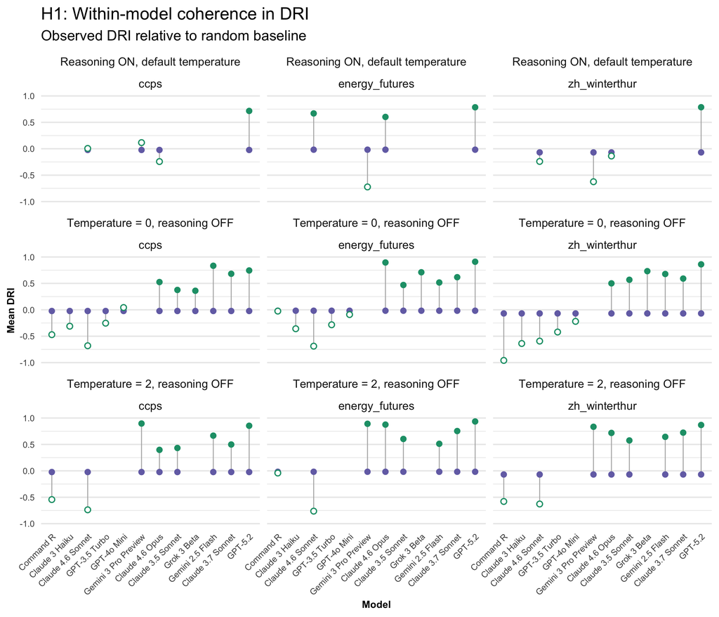

# 5 Other analyses

```
## DATA OVERVIEW
```

```
## Full data rows:  828
```

```
## H2 rows:  828
```

```
## H3 rows:  684
```

```
## H4 rows:  396
```

## 5.1 H2: Model Configuration Effect

```
## boundary (singular) fit: see help('isSingular')
```

```
## H2: MODEL CONFIGURATION EFFECT
```

```
## Linear mixed model fit by maximum likelihood . t-tests use Satterthwaite's
##   method [lmerModLmerTest]
## Formula: dri ~ model_configuration + (1 | role) + (1 | survey)
##    Data: df_h2
##
##       AIC       BIC    logLik -2*log(L)  df.resid
##     557.8     680.5    -252.9     505.8       802
##
## Scaled residuals:
##     Min      1Q  Median      3Q     Max
## -3.8863 -0.5383  0.0373  0.5127  3.8215
##
## Random effects:
##  Groups   Name        Variance Std.Dev.
##  role     (Intercept) 0.001598 0.03998
##  survey   (Intercept) 0.004552 0.06747
##  Residual             0.105833 0.32532
## Number of obs: 828, groups:  role, 12; survey, 3
##
## Fixed effects:
##                                                         Estimate Std. Error
## (Intercept)                                             -0.43569    0.06775
## model_configurationClaude 3.5 Sonnet | temp = 0          0.90698    0.07668
## model_configurationClaude 3.5 Sonnet | temp = 2          0.97292    0.07668
## model_configurationClaude 3.7 Sonnet | temp = 0          1.06585    0.07668
## model_configurationClaude 3.7 Sonnet | temp = 2          1.09410    0.07668
## model_configurationClaude 4.6 Opus | reasoner = 1        0.50999    0.07668
## model_configurationClaude 4.6 Opus | temp = 0            1.07615    0.07668
## model_configurationClaude 4.6 Opus | temp = 2            1.09913    0.07668
## model_configurationClaude 4.6 Sonnet | reasoner = 1      0.58069    0.07668
## model_configurationClaude 4.6 Sonnet | temp = 0         -0.21811    0.07668
## model_configurationClaude 4.6 Sonnet | temp = 2         -0.27378    0.07668
## model_configurationCommand R | temp = 0                 -0.04887    0.07668
## model_configurationCommand R | temp = 2                  0.04746    0.07668
## model_configurationGemini 2.5 Flash | temp = 0           1.11173    0.07668
## model_configurationGemini 2.5 Flash | temp = 2           1.04306    0.07668
## model_configurationGemini 3 Pro Preview | reasoner = 1   0.02550    0.07668
## model_configurationGemini 3 Pro Preview | temp = 2       1.30918    0.07668
## model_configurationGPT-3.5 Turbo | temp = 0              0.11654    0.07668
## model_configurationGPT-4o Mini | temp = 0                0.34691    0.07668
```

[output cut: 39 more lines]

```
## model_configurationClaude 4.6 Sonnet | temp = 2        0.000377 ***
## model_configurationCommand R | temp = 0                0.524066
## model_configurationCommand R | temp = 2                0.536153
## model_configurationGemini 2.5 Flash | temp = 0          < 2e-16 ***
## model_configurationGemini 2.5 Flash | temp = 2          < 2e-16 ***
## model_configurationGemini 3 Pro Preview | reasoner = 1 0.739600
## model_configurationGemini 3 Pro Preview | temp = 2      < 2e-16 ***
## model_configurationGPT-3.5 Turbo | temp = 0            0.128922
## model_configurationGPT-4o Mini | temp = 0              6.97e-06 ***
## model_configurationGPT-5.2 | reasoner = 1               < 2e-16 ***
## model_configurationGPT-5.2 | temp = 0                   < 2e-16 ***
## model_configurationGPT-5.2 | temp = 2                   < 2e-16 ***
## model_configurationGrok 3 Beta | temp = 0               < 2e-16 ***
## ---
## Signif. codes:  0 '***' 0.001 '**' 0.01 '*' 0.05 '.' 0.1 ' ' 1
```

```
##
## Correlation matrix not shown by default, as p = 23 > 12.
## Use print(summary(m_h2), correlation=TRUE)  or
##     vcov(summary(m_h2))        if you need it
```

```
## Type III Analysis of Variance Table with Satterthwaite's method
##                     Sum Sq Mean Sq NumDF  DenDF F value    Pr(>F)
## model_configuration  240.1  10.914    22 813.85  103.12 < 2.2e-16 ***
## ---
## Signif. codes:  0 '***' 0.001 '**' 0.01 '*' 0.05 '.' 0.1 ' ' 1
```

```
## Data: df_h2
## Models:
## m_h2_null: dri ~ (1 | role) + (1 | survey)
## m_h2: dri ~ model_configuration + (1 | role) + (1 | survey)
##           npar     AIC     BIC  logLik -2*log(L)  Chisq Df Pr(>Chisq)
## m_h2_null    4 1599.29 1618.17 -795.65   1591.29
## m_h2        26  557.76  680.46 -252.88    505.76 1085.5 22  < 2.2e-16 ***
## ---
## Signif. codes:  0 '***' 0.001 '**' 0.01 '*' 0.05 '.' 0.1 ' ' 1
```

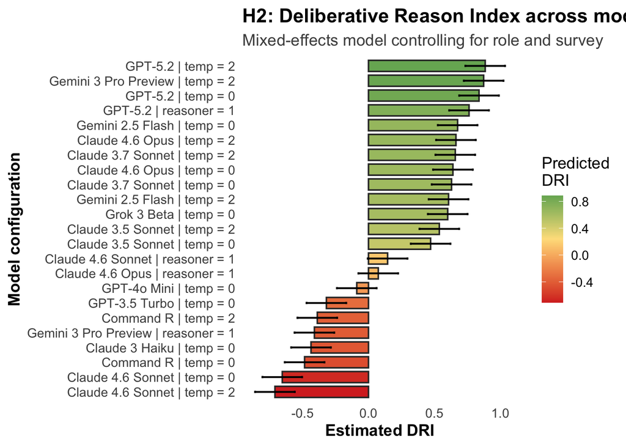

## 5.2 H3: Temperature Effect

```
## H3: TEMPERATURE EFFECT
```

```
## Linear mixed model fit by REML. t-tests use Satterthwaite's method [
## lmerModLmerTest]
## Formula: dri ~ temperature + (1 | model) + (1 | survey)
##    Data: df_h3
##
## REML criterion at convergence: 220.1
##
## Scaled residuals:
##     Min      1Q  Median      3Q     Max
## -3.6610 -0.5524  0.0421  0.5525  3.2275
##
## Random effects:
##  Groups   Name        Variance Std.Dev.
##  model    (Intercept) 0.32860  0.57323
##  survey   (Intercept) 0.00398  0.06309
##  Residual             0.07221  0.26872
## Number of obs: 684, groups:  model, 12; survey, 3
##
## Fixed effects:
##               Estimate Std. Error        df t value Pr(>|t|)
## (Intercept)    0.22698    0.17003  11.96984   1.335    0.207
## temperature2   0.02100    0.02392 671.32457   0.878    0.380
##
## Correlation of Fixed Effects:
##             (Intr)
## temperatur2 -0.053
```

```
## Type III Analysis of Variance Table with Satterthwaite's method
##               Sum Sq  Mean Sq NumDF  DenDF F value Pr(>F)
## temperature 0.055643 0.055643     1 671.32  0.7705 0.3804
```

## 5.3 H4: Reasoning Effect

```
## H4: REASONING EFFECT
```

```
## Linear mixed model fit by REML. t-tests use Satterthwaite's method [
## lmerModLmerTest]
## Formula: dri ~ reasoner_n + (1 | model) + (1 | survey)
##    Data: df_h4
##
## REML criterion at convergence: 628
##
## Scaled residuals:
##      Min       1Q   Median       3Q      Max
## -2.80865 -0.52321  0.03568  0.57056  2.95954
##
## Random effects:
##  Groups   Name        Variance Std.Dev.
##  model    (Intercept) 0.265835 0.51559
##  survey   (Intercept) 0.008241 0.09078
##  Residual             0.268857 0.51851
## Number of obs: 396, groups:  model, 4; survey, 3
##
## Fixed effects:
##              Estimate Std. Error        df t value Pr(>|t|)
## (Intercept)   0.35978    0.26519   3.28425   1.357    0.261
## reasoner_n1  -0.21685    0.05465 389.18369  -3.968 8.63e-05 ***
## ---
## Signif. codes:  0 '***' 0.001 '**' 0.01 '*' 0.05 '.' 0.1 ' ' 1
##
## Correlation of Fixed Effects:
##             (Intr)
## reasoner_n1 -0.077
```

```
## Type III Analysis of Variance Table with Satterthwaite's method
##            Sum Sq Mean Sq NumDF  DenDF F value   Pr(>F)
## reasoner_n 4.2331  4.2331     1 389.18  15.745 8.63e-05 ***
## ---
## Signif. codes:  0 '***' 0.001 '**' 0.01 '*' 0.05 '.' 0.1 ' ' 1
```

```
## `height` was translated to `width`.
## `height` was translated to `width`.
```

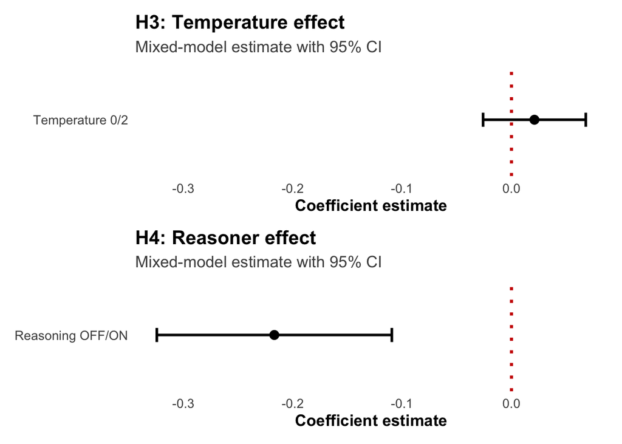

```
## `height` was translated to `width`.
## `height` was translated to `width`.
```

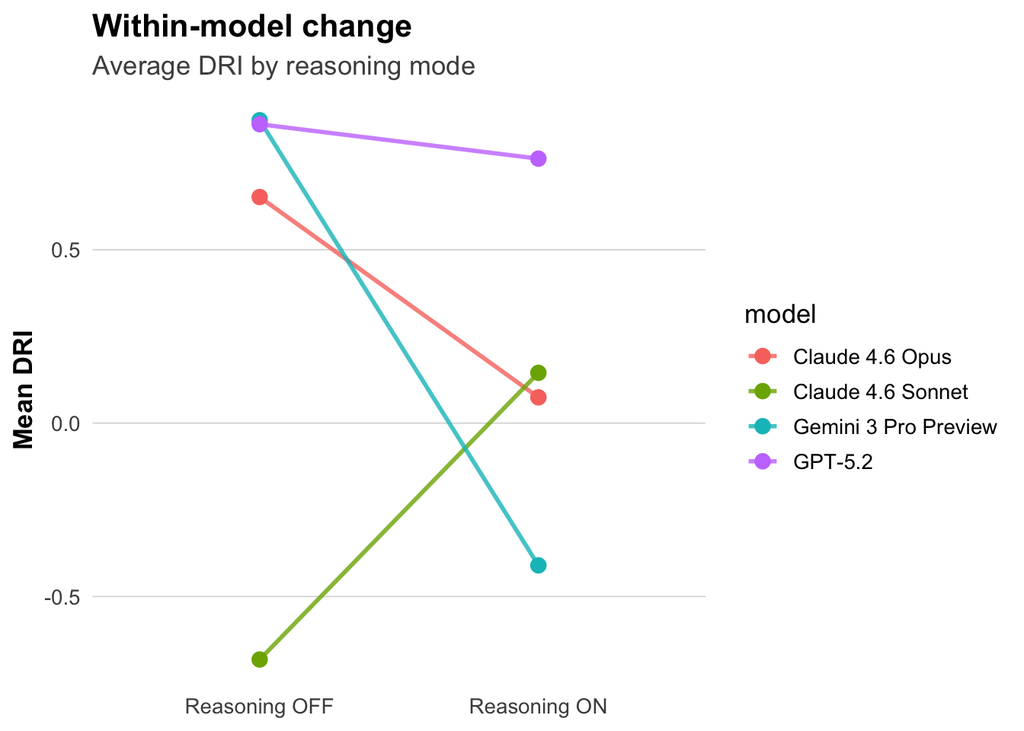

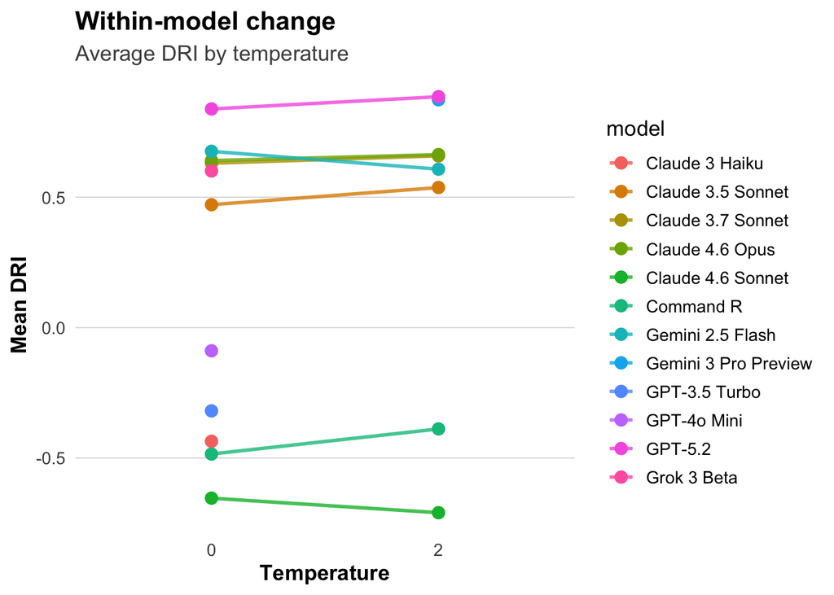

```
## `height` was translated to `width`.
```

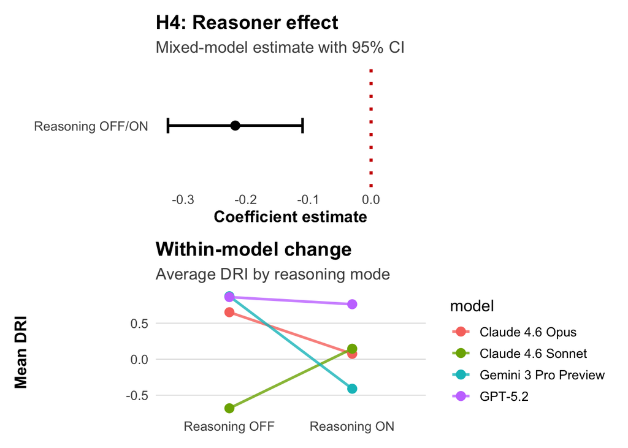

```
## `height` was translated to `width`.
```

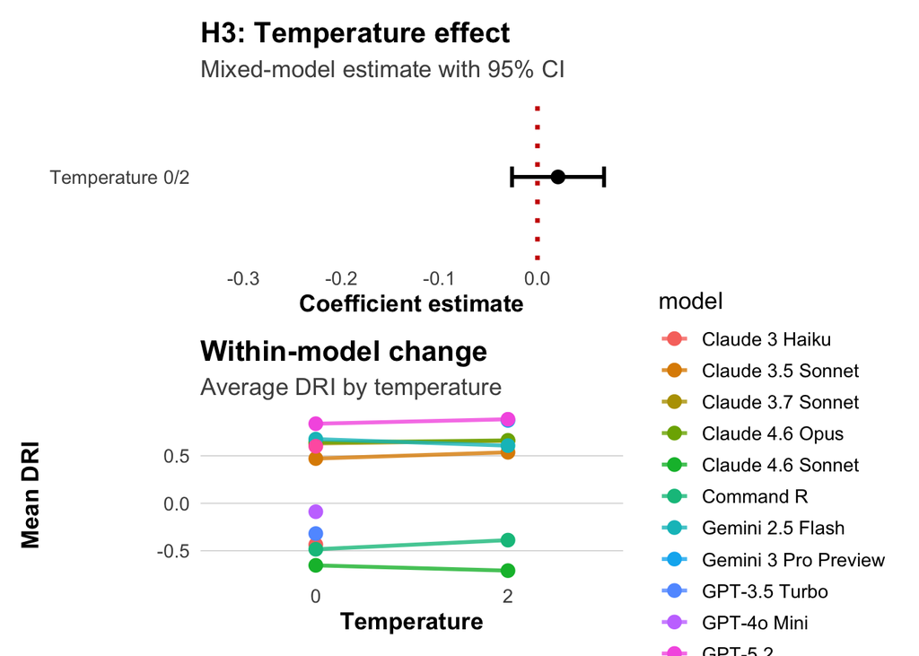

[^1]: Note that `gemini-2.5-pro-preview-03-25` was replaced by `gemini-2.5-pro`, however, this version of the model became significantly slower and more expensive, since it has “thinking” enabled by default and cannot be toggled. As a result, we decided to use the *flash* version (`gemini-2.5-flash`), a lighter and cheaper alternative.